# Homework 4 Solutions

## 4(d) Results

```r
tune_res |>
  slice_head(n = 10) |>
  kbl2(digits = 3, caption = "Top 10 Configurations by Validation AUC")
```

Top 10 Configurations by Validation AUC

| arch | p_drop | wd | lr | epochs | train_auc | val_auc |
| --- | --- | --- | --- | --- | --- | --- |
| 4 | 0.3 | 0.010 | 0.001 | 100 | 1.000 | 0.882 |
| 4 | 0.3 | 0.000 | 0.001 | 94 | 1.000 | 0.881 |
| 4 | 0.3 | 0.001 | 0.001 | 90 | 1.000 | 0.878 |
| 8-4 | 0.3 | 0.001 | 0.010 | 15 | 1.000 | 0.875 |
| 4 | 0.3 | 0.001 | 0.010 | 17 | 0.999 | 0.874 |
| 8 | 0.3 | 0.000 | 0.010 | 14 | 1.000 | 0.874 |
| 8-4 | 0.3 | 0.010 | 0.010 | 20 | 1.000 | 0.872 |
| 4 | 0.3 | 0.000 | 0.010 | 17 | 0.998 | 0.872 |
| 8 | 0.3 | 0.001 | 0.010 | 14 | 1.000 | 0.869 |
| 8-4 | 0.3 | 0.010 | 0.001 | 63 | 0.999 | 0.867 |

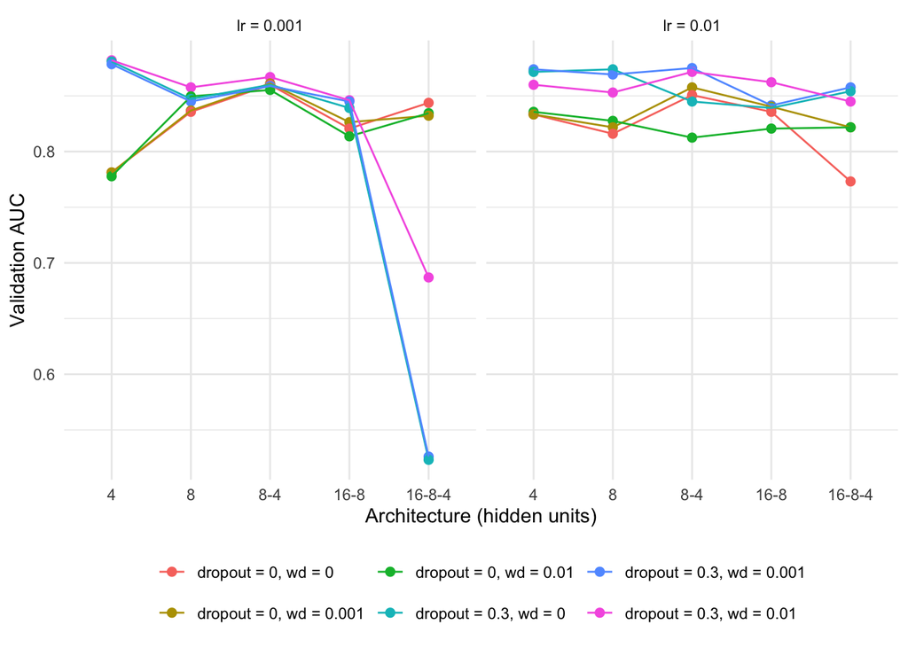

```r
tune_res |>
  mutate(reg  = paste0("dropout = ", p_drop, ", wd = ", wd),
         lr   = paste("lr =", lr),
         arch = factor(arch, levels = names(archs))) |>
  ggplot(aes(arch, val_auc, colour = reg, group = reg)) +
  geom_point(size = 2) + geom_line() +
  facet_wrap(~lr) +
  labs(x = "Architecture (hidden units)", y = "Validation AUC", colour = NULL) +
  theme_minimal() + theme(legend.position = "bottom")
```

```r
tune_res |>
  mutate(gap = train_auc - val_auc,
         regularized = ifelse(p_drop > 0 | wd > 0, "dropout and/or weight decay", "none")) |>
  group_by(regularized) |>
  summarise(mean_train_auc = mean(train_auc), mean_val_auc = mean(val_auc),
            mean_gap = mean(gap), mean_epochs = mean(epochs)) |>
  kbl2(digits = 3, caption = "Effect of regularization (averaged over the grid)")
```

Effect of regularization (averaged over the grid)

| regularized | mean_train_auc | mean_val_auc | mean_gap | mean_epochs |
| --- | --- | --- | --- | --- |
| dropout and/or weight decay | 0.978 | 0.830 | 0.148 | 31.88 |
| none | 0.998 | 0.825 | 0.173 | 26.80 |

```r
best <- tune_res |> slice_head(n = 1)
best |> kbl2(digits = 3, caption = "Selected Configuration")
```

Selected Configuration

| arch | p_drop | wd | lr | epochs | train_auc | val_auc |
| --- | --- | --- | --- | --- | --- | --- |
| 4 | 0.3 | 0.01 | 0.001 | 100 | 1 | 0.882 |

## 4(e) Lasso and Random Forest, and Thresholds

Both comparison models are tuned using the training data only (5-fold CV); the validation set is used, as for the network, to pick the classification threshold. The lasso logistic regression uses `cv.glmnet()` with cross-validated AUC as the criterion.

```r
x_train <- as.matrix(select(train, -Class))
x_val   <- as.matrix(select(val,   -Class))
x_test  <- as.matrix(select(test,  -Class))

# Lasso logistic regression (the second level of Class, "Impaired", is the event)
set.seed(4)
cv_lasso <- cv.glmnet(x_train, train$Class, family = "binomial", alpha = 1,
                      type.measure = "auc", nfolds = 5)
cv_lasso
```

```
Call:  cv.glmnet(x = x_train, y = train$Class, type.measure = "auc",      nfolds = 5, family = "binomial", alpha = 1)

Measure: AUC

     Lambda Index Measure      SE Nonzero
min 0.04867    16  0.9040 0.02359      13
1se 0.07749    11  0.8849 0.01997       9
```

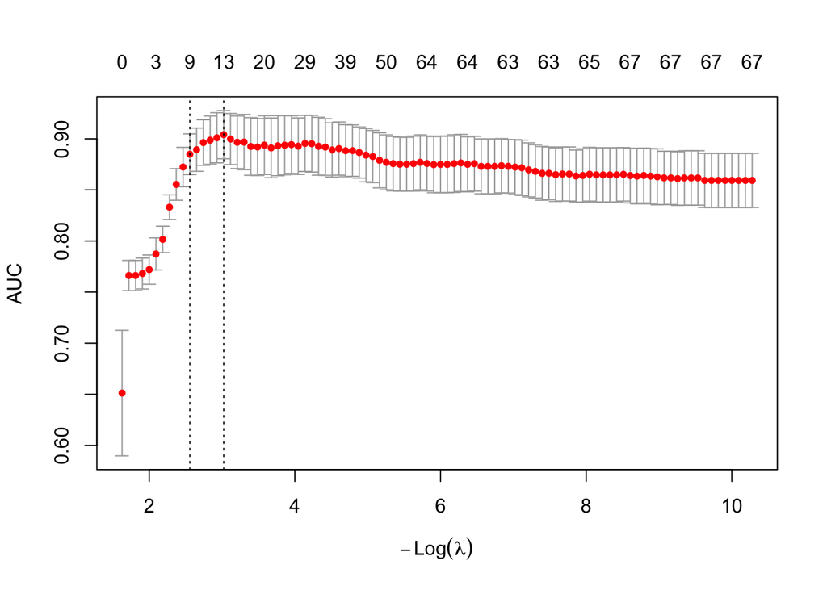

```r
plot(cv_lasso)
```

```r
c(n_nonzero = sum(coef(cv_lasso, s = "lambda.min")[-1] != 0), n_predictors = n_features)
```

```
   n_nonzero n_predictors
          13          134
```

```r
to_caret <- function(d) mutate(d, Class = factor(ifelse(Class == "Impaired", "yes", "no"),
                                                 levels = c("no", "yes")))
train_c <- to_caret(train); val_c <- to_caret(val); test_c <- to_caret(test)

ctrl <- trainControl(method = "cv", number = 5, classProbs = TRUE,
                     summaryFunction = twoClassSummary)

# Random forest
set.seed(4)
rf_fit <- caret::train(
  Class ~ ., data = train_c, method = "rf", ntree = 500, metric = "ROC", trControl = ctrl,
  tuneGrid = data.frame(mtry = c(2, 5, 10, 20, 40, 80, n_features))
)
rf_fit$bestTune
```

```
  mtry
3   10
```

```r
fit_best <- fit_mlp(archs[[best$arch]], best$p_drop, best$wd, best$lr)

p_val <- list(
  "Neural network" = get_probs(fit_best, x_val_t)[, 2],
  "Lasso"          = as.numeric(predict(cv_lasso, newx = x_val, s = "lambda.min", type = "response")),
  "Random forest"  = predict(rf_fit,    val_c, type = "prob")[, "yes"]
)

tune_threshold_j <- function(truth, prob) {
  truth <- factor(truth, levels = c(0, 1))
  js <- sapply(sort(unique(prob)), function(t) {
    cls <- factor(ifelse(prob >= t, 1, 0), levels = c(0, 1))
    as.numeric(sens_vec(truth, cls, event_level = "second") +
               spec_vec(truth, cls, event_level = "second") - 1)
  })
  sort(unique(prob))[which.max(js)]
}

thr <- sapply(p_val, function(p) tune_threshold_j(y_val, p))
thr
```

```
Neural network          Lasso  Random forest
     0.4501632      0.2264994      0.4060000
```

## 4(f) Test-Set Evaluation

The test set is used once, with the thresholds chosen on the validation set.

```r
p_test <- list(
  "Neural network" = get_probs(fit_best, x_test_t)[, 2],
  "Lasso"          = as.numeric(predict(cv_lasso, newx = x_test, s = "lambda.min", type = "response")),
  "Random forest"  = predict(rf_fit,    test_c, type = "prob")[, "yes"]
)

map_dfr(names(p_test), function(m) {
  eval_metrics(y_test, p_test[[m]], thr = thr[[m]]) |>
    mutate(Model = m, Threshold = thr[[m]], .before = AUC)
}) |>
  select(Model, Threshold, AUC, Sens, Spec, Acc) |>
  kbl2(digits = 3, caption = "Final Test-Set Performance (thresholds from validation)")
```

Final Test-Set Performance (thresholds from validation)

| Model | Threshold | AUC | Sens | Spec | Acc |
| --- | --- | --- | --- | --- | --- |
| Neural network | 0.450 | 0.743 | 0.632 | 0.796 | 0.750 |
| Lasso | 0.226 | 0.858 | 0.842 | 0.878 | 0.868 |
| Random forest | 0.406 | 0.889 | 0.421 | 0.980 | 0.824 |

> **Interpretation:** On the test set, the random forest (AUC 0.89) and the lasso (AUC 0.86) are clearly better than the neural network (AUC 0.74), even though the network looked competitive on the validation set (0.88). That drop is the “winner’s curse” of choosing the best of 60 networks on 66 patients; the lasso (13 of 134 predictors kept at `lambda.min`) and random forest were tuned by cross-validation on the training data, so their numbers are less optimistic.

> At the thresholds chosen on the validation set, the lasso gives the best balance of sensitivity (0.84) and specificity (0.88); the random forest has a slightly higher AUC but, at its threshold, a much lower sensitivity (0.42) with very high specificity (0.98). With only 19 impaired patients in the test set, each sensitivity rests on very few patients and has a wide confidence interval, and the AUC differences between the lasso and random forest are well within noise.

> **Recommendation:** the lasso logistic regression, which performs about as well as the random forest, is simplest to explain, and selects a small, sparse set of biomarkers.

## 4(g) Discussion

- **Risks with this data.** With only a few hundred patients and 130 predictors (more predictors than a reasonable number of events), a flexible network can fit the training data perfectly (as seen with a training AUC near 1), so performance estimates are noisy, tuning on a tiny validation set overfits the validation data, and results depend heavily on the random split and initialization. Thresholds chosen on so few patients are unstable. Cross-validation, repeated splits, or averaging over seeds would give more trustworthy comparisons.
- **When neural networks are overkill.** When data are small or low-dimensional, tabular, and mostly smooth or linear in the predictors, penalized regression, trees, or random forests usually match a neural network and are far easier to tune, explain to clinicians, and validate, as we saw here. Networks tend to pay off with very large samples or unstructured inputs such as images (the chest X-ray example), text, or signals. In public health, interpretability, calibration, and the ability to audit a model for fairness often matter as much as a small gain in AUC.

# Question 5: Global versus Local Structure

You are studying a dataset of 500 patients, each with 200 biomarkers measured at baseline. You plan to visualize the relationships between individuals using a low-dimensional embedding (2D or 3D). Consider the following situations and state whether a **global** or **local** dimension reduction method would be more appropriate. Justify your answer in 2–3 sentences.

1. You believe there is a single underlying continuous “disease severity” score that explains most of the biomarker variation.

Because the goal is to uncover a single latent “disease severity” construct that drives the biomarker patterns across all patients, a **global dimension reduction method** is most appropriate. Global methods (e.g., PCA, factor analysis) capture the dominant sources of variation in the entire dataset and can reveal overarching continuous scores that summarize overall severity.

2. You are interested in identifying small subgroups of patients with very similar biomarker profiles but distinct from the rest of the population.

Here the goal is to detect **small, homogeneous subgroups** of patients who differ from the rest of the population, so a **local dimension reduction method** is more suitable. Local methods (e.g., UMAP, t-SNE, Isomap) preserve neighborhood structure and emphasize local similarities, making them effective for revealing subtle clusters that global methods may smooth over.

3. You plan to create a 2D visualization of single-cell RNA expression data to identify cell-type clusters.

For visualizing single-cell RNA-seq data and identifying cell-type clusters, a **local dimension reduction method** such as t-SNE or UMAP is appropriate. These methods preserve fine-grained local relationships and therefore allow biologically similar cells to cluster together in low-dimensional space, whereas global methods often miss these subtle but important boundaries.

4. You have time-series physiological data (e.g., heart rate, sleep, and activity) and want to summarize the overall level and variability across participants.

If the goal is to summarize broad patterns–such as overall levels and variability in time-series physiological measures across participants–a **global dimension reduction method** is most appropriate. Global methods highlight major sources of variation shared across the dataset and provide low-dimensional summaries of overall behavior rather than focusing on small local deviations.